# Results Thesis

Gurudev Ilangovan

5/1/2019

## Effect of N on performance

### Effect of N on F1 for different models

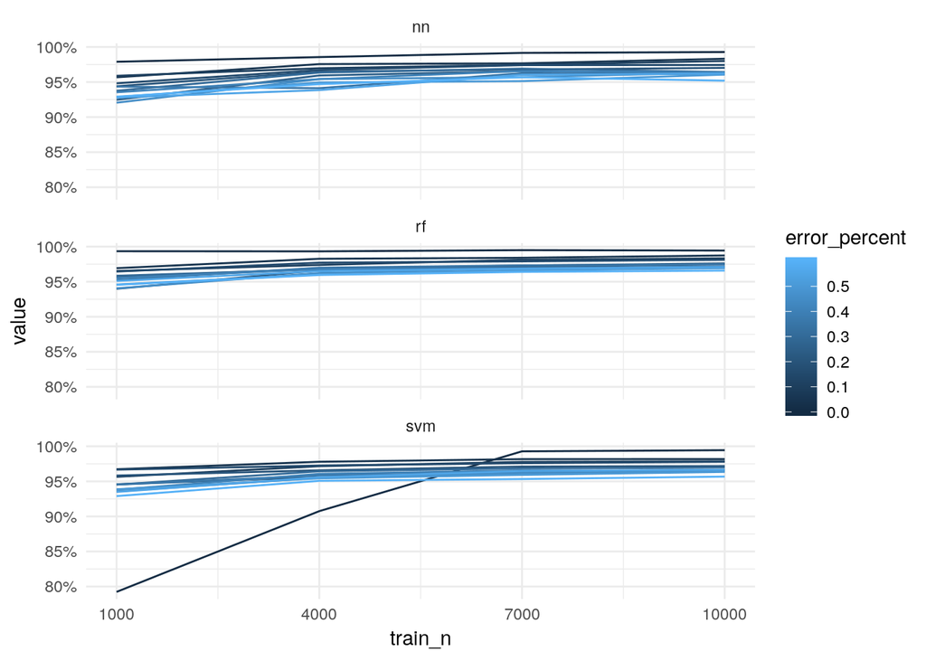

As expected, when the amount of training data is increased, the model performance measured by F1 shows improvement, irrespective of the algorithm. The rate of increase in performance is the highest initially. At n=7000, the performance plateaus and there is not a lot of gains in F1 after that. Also, in line with expectations, at higher error rates, performance is lower than cleaner datasets for the same amount of training data.

```
##                 Df Sum Sq Mean Sq F value Pr(>F)
## train_n          1 0.1604 0.16035   526.2 <2e-16 ***
## model            2 0.0403 0.02014    66.1 <2e-16 ***
## error_percent    1 0.0790 0.07897   259.2 <2e-16 ***
## Residuals     1555 0.4739 0.00030
## ---
## Signif. codes:  0 '***' 0.001 '**' 0.01 '*' 0.05 '.' 0.1 ' ' 1
```

### Effect of N on review size for different models

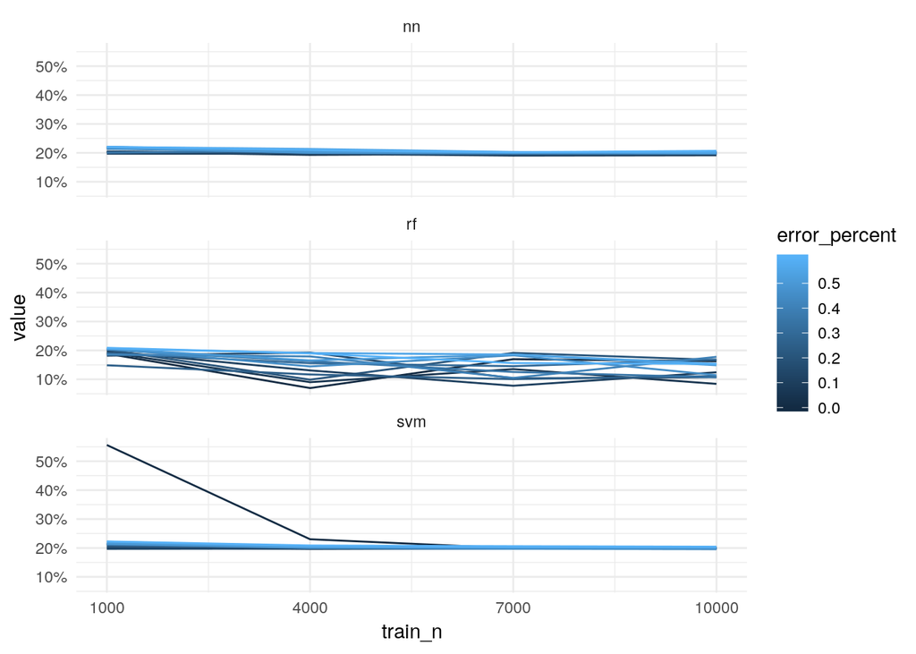

The percentage of manual review however is interesting. For neural nets and svm, the review set size remains largely constant as we increase the training data size and any improvement is negligible in comparison with random forests. In random forests, there is a lot of variance in the review size at different training set sizes but the review size improves the most as more training data is added. Also, the review size for different error rates at a given training set size shows a lot of variance unlike with neural nets and svms.

```
##                 Df Sum Sq Mean Sq F value  Pr(>F)
## train_n          1 0.2284  0.2284   157.2 < 2e-16 ***
## model            2 0.9411  0.4706   323.9 < 2e-16 ***
## error_percent    1 0.0153  0.0153    10.5 0.00122 **
## Residuals     1555 2.2593  0.0015
## ---
## Signif. codes:  0 '***' 0.001 '**' 0.01 '*' 0.05 '.' 0.1 ' ' 1
```

## Effect of error rate on performance

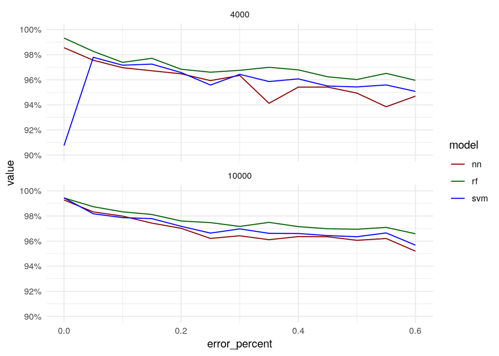

It is clear that F1 score goes down as we increase the error rate for all models. However at N=10,000, there is a lot less variation between the performances of different models at various error rates. Even though Random Forests outperform the other 2 algorithms at N=10000, there is barely any difference between them at error rate 0%. At higher error rates, random forest gradually outperform svms and neural nets.

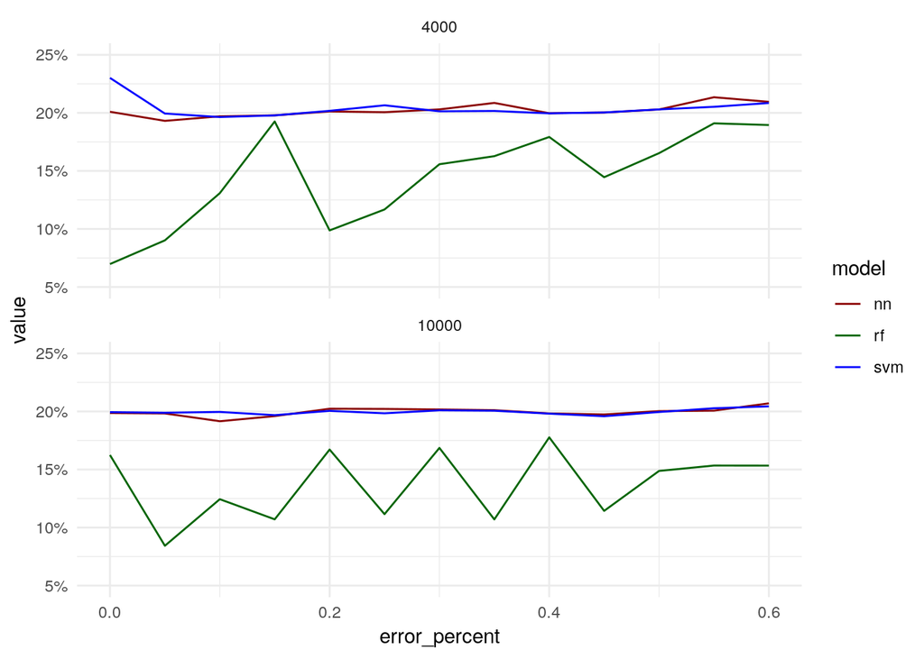

The review size also goes up as error rate increases. Though random forests show a lot of variation in the performance, they alawys perform better than the other 2 models

```
##
##  Paired t-test
##
## data:  rf_4000 and nn_4000
## t = 2.8655, df = 9, p-value = 0.9907
## alternative hypothesis: true difference in means is less than 0
## 95 percent confidence interval:
##        -Inf 0.00269073
## sample estimates:
## mean of the differences
##             0.001640966
```

```
##
##  Welch Two Sample t-test
##
## data:  rf_4000 and nn_4000
## t = 0.94891, df = 17.891, p-value = 0.1777
## alternative hypothesis: true difference in means is greater than 0
## 95 percent confidence interval:
##  -0.0013864        Inf
## sample estimates:
## mean of x mean of y
## 0.9944567 0.9927823
```

```
## # A tibble: 2 x 2
##   model     n
##   <chr> <int>
## 1 rf       48
## 2 svm       4
```

```
## # A tibble: 4 x 6
##   train_n model metric error_percent  mean      sd
##     <dbl> <chr> <chr>          <dbl> <dbl>   <dbl>
## 1    1000 svm   f1              0.15 0.967 0.00607
## 2    1000 svm   f1              0.2  0.958 0.0102
## 3    1000 svm   f1              0.25 0.946 0.00626
## 4   10000 svm   f1              0    0.994 0.00379
```

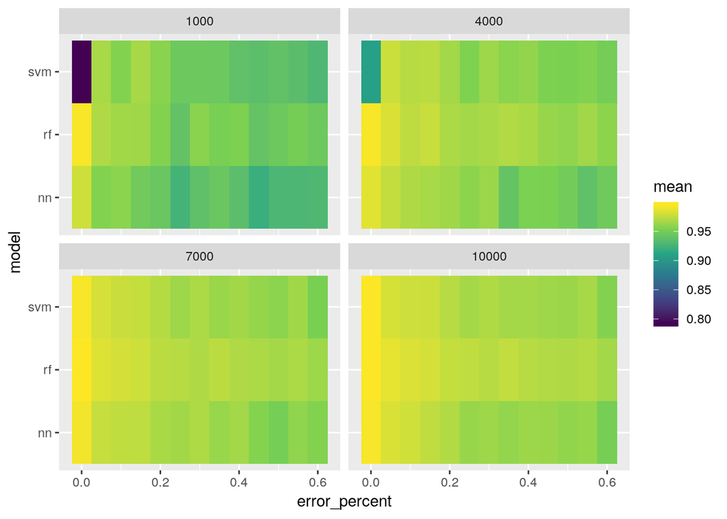

```
## # A tibble: 2 x 2
##   model     n
##   <chr> <int>
## 1 nn        3
## 2 rf       50
```

```
## # A tibble: 3 x 5
##   train_n model metric        error_percent value
##     <dbl> <chr> <chr>                 <dbl> <dbl>
## 1    1000 nn    review_pct_99          0.1  0.197
## 2    1000 nn    review_pct_99          0.2  0.202
## 3    1000 nn    review_pct_99          0.35 0.200
```